# **Homework_Week5**

Shivani

# 1 Contents

1. Loading data
2. Visualizing data
3. Fitting an appropriate GLM
4. Assessing the fit of our model
5. Multiple comparisons test
6. Plotting co-efficients
7. Plotting interactions
8. Summary

## 1.1 Loading data

Loading the penguin data and Filtering NA values

```r
#loading the respective libraries
library(palmerpenguins)
library(knitr)
#viewing the data
kable(head(penguins))
```

| species | island | bill_length_mm | bill_depth_mm | flipper_length_mm | body_mass_g | sex | year |
| --- | --- | --- | --- | --- | --- | --- | --- |
| Adelie | Torgersen | 39.1 | 18.7 | 181 | 3750 | male | 2007 |
| Adelie | Torgersen | 39.5 | 17.4 | 186 | 3800 | female | 2007 |
| Adelie | Torgersen | 40.3 | 18.0 | 195 | 3250 | female | 2007 |
| Adelie | Torgersen | NA | NA | NA | NA | NA | 2007 |
| Adelie | Torgersen | 36.7 | 19.3 | 193 | 3450 | female | 2007 |
| Adelie | Torgersen | 39.3 | 20.6 | 190 | 3650 | male | 2007 |

```r
#loading the respective libraries
library(palmerpenguins)
library(knitr)
library(tidyverse)
penguins_filter <-
  #taking original data set
  penguins %>%
  #filtering out any values equal to NA
  drop_na(bill_depth_mm, bill_length_mm, flipper_length_mm, body_mass_g, sex)
  #viewing the filtered data
kable(head(penguins_filter))
```

| species | island | bill_length_mm | bill_depth_mm | flipper_length_mm | body_mass_g | sex | year |
| --- | --- | --- | --- | --- | --- | --- | --- |
| Adelie | Torgersen | 39.1 | 18.7 | 181 | 3750 | male | 2007 |
| Adelie | Torgersen | 39.5 | 17.4 | 186 | 3800 | female | 2007 |
| Adelie | Torgersen | 40.3 | 18.0 | 195 | 3250 | female | 2007 |
| Adelie | Torgersen | 36.7 | 19.3 | 193 | 3450 | female | 2007 |
| Adelie | Torgersen | 39.3 | 20.6 | 190 | 3650 | male | 2007 |
| Adelie | Torgersen | 38.9 | 17.8 | 181 | 3625 | female | 2007 |

## 1.2 Visualizing data

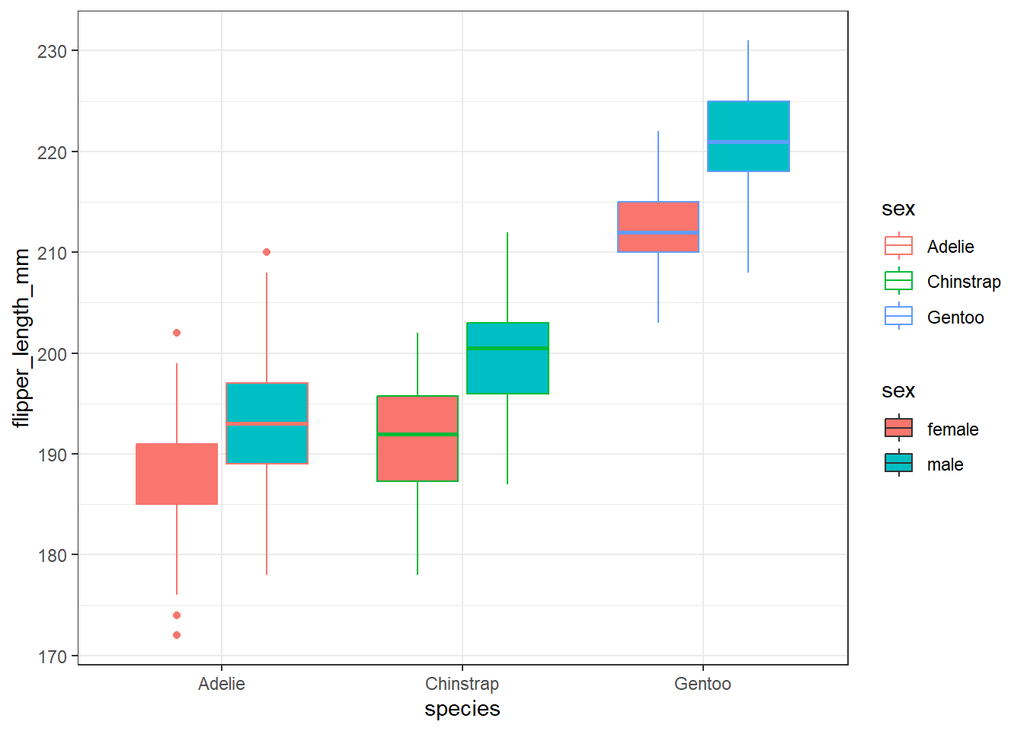

```r
#loading ggplot2
library(ggplot2)
#plotting penguin data to view flipper length trend over different species
ggplot(data = penguins_filter, aes(x = species, y=flipper_length_mm,fill=sex, col=sex))+
  geom_boxplot(aes(col=species))+
  theme_bw()
```

## 1.3 Fitting an appropriate GLM

For this analysis, clearly, Species and sex is the predictive variable and flipper length is the response variable. Since flipper length data is continuous, the data could be fit into normal distribution.

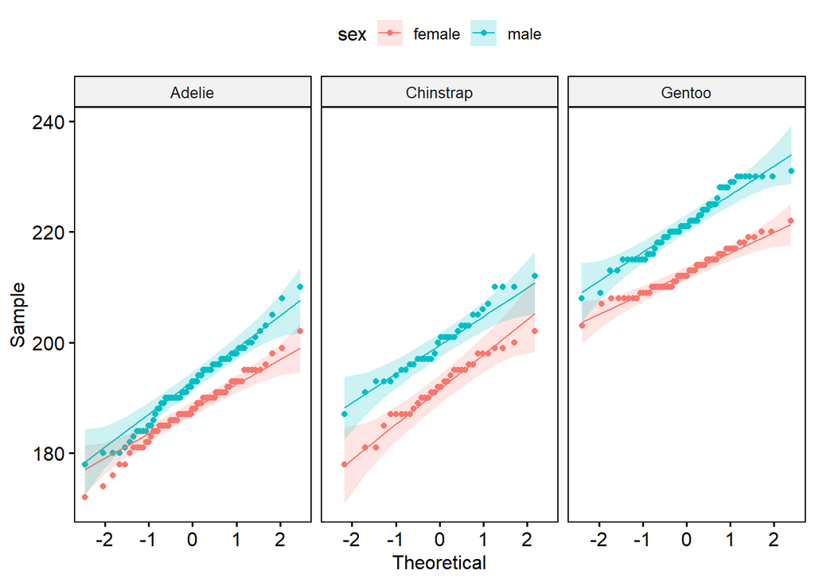

```r
#loading the ggpubr library
library(ggpubr)
#q-q plot to check if the trend is normal
ggqqplot(penguins_filter, x="flipper_length_mm", color="sex", facet.by="species")
```

The above qqplot shows that the data is normally distributed.

## 1.4 Assessing the fit of our model

Let us check gaussian model for our data and view summary for further interpretation

```r
#loading the library
library(tidyverse)
penguins_filter <-
  #taking original data set
  penguins %>%
  #filtering out any values equal to NA
  drop_na(bill_depth_mm, bill_length_mm, flipper_length_mm, body_mass_g, sex)
mod_flipper <- glm(flipper_length_mm ~ species*sex,
                   #specify the data
                   data = penguins_filter,
                   #specify the model
                   family = "gaussian")
summary(mod_flipper) #checking the summary
```

```
##
## Call:
## glm(formula = flipper_length_mm ~ species * sex, family = "gaussian",
##     data = penguins_filter)
##
## Coefficients:
##                          Estimate Std. Error t value Pr(>|t|)
## (Intercept)              187.7945     0.6619 283.721  < 2e-16 ***
## speciesChinstrap           3.9408     1.1742   3.356 0.000884 ***
## speciesGentoo             24.9124     0.9947  25.044  < 2e-16 ***
## sexmale                    4.6164     0.9361   4.932  1.3e-06 ***
## speciesChinstrap:sexmale   3.5600     1.6606   2.144 0.032782 *
## speciesGentoo:sexmale      4.2176     1.3971   3.019 0.002737 **
## ---
## Signif. codes:  0 '***' 0.001 '**' 0.01 '*' 0.05 '.' 0.1 ' ' 1
##
## (Dispersion parameter for gaussian family taken to be 31.98198)
##
##     Null deviance: 65219  on 332  degrees of freedom
## Residual deviance: 10458  on 327  degrees of freedom
## AIC: 2106.9
##
## Number of Fisher Scoring iterations: 2
```

### 1.4.1 Interpretations

Let us plot some interpretations for model prediction versus the obeserved data. Viewing the goodness of the fit using the check_model function

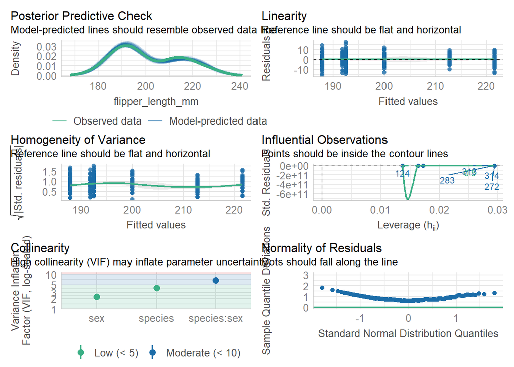

```r
#using performance package
library(performance)
check_model(mod_flipper)
```

Analysing above plots, we could observe that the model predicted data and observed data are quite resembling. There are no severe abnormalities in the plots and hence, we could move on with the further analysis.

## 1.5 Multiple comparisons test

Let us carry out multiple comparison test test to check if there is a significant difference between flipper length and species.

```r
#install.packages("multcomp")
library(multcomp)
#viewing the summary of the model
summary(glht(mod_flipper,mcp(species="Tukey")))
```

```
##
##   Simultaneous Tests for General Linear Hypotheses
##
## Multiple Comparisons of Means: Tukey Contrasts
##
##
## Fit: glm(formula = flipper_length_mm ~ species * sex, family = "gaussian",
##     data = penguins_filter)
##
## Linear Hypotheses:
##                         Estimate Std. Error z value Pr(>|z|)
## Chinstrap - Adelie == 0   3.9408     1.1742   3.356  0.00223 **
## Gentoo - Adelie == 0     24.9124     0.9947  25.044  < 0.001 ***
## Gentoo - Chinstrap == 0  20.9716     1.2215  17.169  < 0.001 ***
## ---
## Signif. codes:  0 '***' 0.001 '**' 0.01 '*' 0.05 '.' 0.1 ' ' 1
## (Adjusted p values reported -- single-step method)
```

p value for Chinstrap - Adelie, Gentoo - Adelie and Gentoo - Chinstrap are all <<0.05. Meaning, the predictor is statistically significant.

## 1.6 Plotting co-efficients

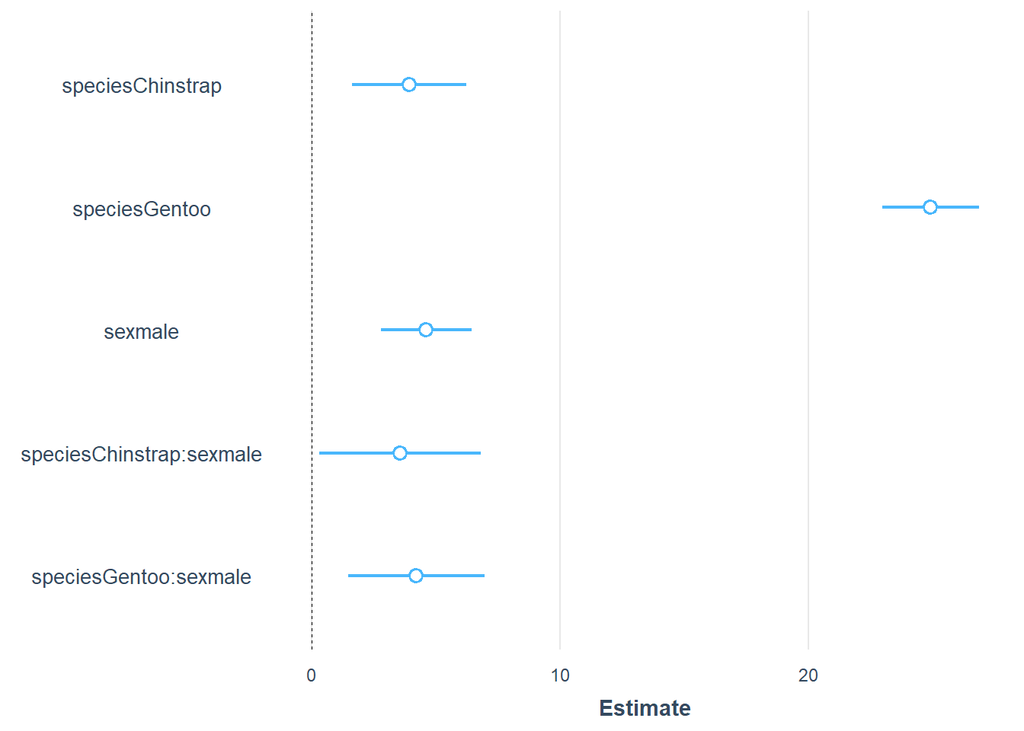

```r
#loading the library
library(jtools)
#producing co-efficient plot
plot_summs(mod_flipper)
```

Here, each point refers to the estimated effect of species and sex on the flipper length based on gaussian model.

## 1.7 Plotting interactions

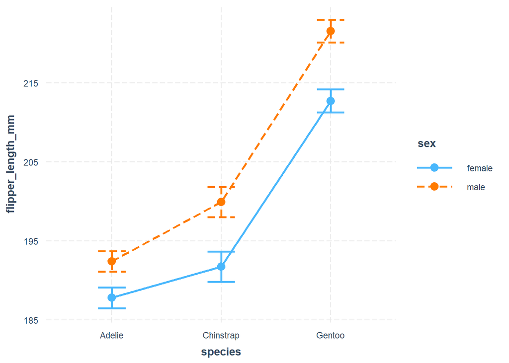

```r
#loading the library
library(jtools)
library(interactions)
#building the model
model <- lm(flipper_length_mm ~ species * sex, data = penguins_filter)
#plotting the interaction b/w predictive and response variables
interact_plot(model, pred = species, modx = sex, interval = TRUE)
```

This plot suggests that species and sex has a varying impact on the flipper length. Since it is already been observed that there is significant difference in flipper lengths between the 3 species, interactively, males have higher flipper length than females. This plot is useful for understanding how sex moderates the effect of species on the outcome variable-flipper length.